# Försäkringskostnader

Malin

2026-04-01

# Försäkringsanalys

Försäkringsbranschen bygger på förmågan att korrekt bedöma och prissätta risk. För att säkerställa att prissättningen återspeglar de faktiska kostnadsdrivarna har en analys genomförts av bolagets historiska kunddata, med fokus på demografiska egenskaper, livsstilsfaktorer och hälsorelaterade variabler.

Rapporten presenterar en explorativ dataanalys följt av en regressionsanalys i syfte att identifiera vilka variabler som har starkast samband med försäkringskostnaderna. Resultaten är avsedda att utgöra ett underlag för ledningsgruppens arbete med framtida prissättningsstrategier.

## 1. Dataförståelse

```r
library(tidyverse)
library(skimr)
library(patchwork)

cost_raw <- read.csv("insurance_costs.csv")

tibble(
  variabel = names(cost_raw),
  datatyp = sapply(cost_raw, class)
) |> knitr::kable()
```

| variabel | datatyp |
| --- | --- |
| customer_id | character |
| age | integer |
| sex | character |
| region | character |
| bmi | numeric |
| children | integer |
| smoker | character |
| chronic_condition | character |
| exercise_level | character |
| plan_type | character |
| prior_accidents | integer |
| prior_claims | integer |
| annual_checkups | numeric |
| charges | numeric |

```r
skim_without_charts(cost_raw)
```

Data summary

| Name | cost_raw |
| --- | --- |
| Number of rows | 1100 |
| Number of columns | 14 |
| _______________________ |  |
| Column type frequency: |  |
| character | 7 |
| numeric | 7 |
| ________________________ |  |
| Group variables | None |

**Variable type: character**

| skim_variable | n_missing | complete_rate | min | max | empty | n_unique | whitespace |
| --- | --- | --- | --- | --- | --- | --- | --- |
| customer_id | 0 | 1 | 7 | 7 | 0 | 1100 | 0 |
| sex | 0 | 1 | 4 | 6 | 0 | 2 | 0 |
| region | 0 | 1 | 4 | 6 | 0 | 6 | 0 |
| smoker | 0 | 1 | 2 | 3 | 0 | 4 | 0 |
| chronic_condition | 0 | 1 | 2 | 3 | 0 | 2 | 0 |
| exercise_level | 0 | 1 | 0 | 6 | 22 | 4 | 0 |
| plan_type | 0 | 1 | 5 | 8 | 0 | 6 | 0 |

**Variable type: numeric**

| skim_variable | n_missing | complete_rate | mean | sd | p0 | p25 | p50 | p75 | p100 |
| --- | --- | --- | --- | --- | --- | --- | --- | --- | --- |
| age | 0 | 1.00 | 42.51 | 12.37 | 18.00 | 34.00 | 42.50 | 51.00 | 75.00 |
| bmi | 28 | 0.97 | 27.43 | 4.59 | 17.00 | 24.30 | 27.50 | 30.60 | 44.00 |
| children | 0 | 1.00 | 1.57 | 1.47 | 0.00 | 0.00 | 1.00 | 3.00 | 5.00 |
| prior_accidents | 0 | 1.00 | 0.24 | 0.50 | 0.00 | 0.00 | 0.00 | 0.00 | 3.00 |
| prior_claims | 0 | 1.00 | 0.27 | 0.53 | 0.00 | 0.00 | 0.00 | 0.00 | 3.00 |
| annual_checkups | 20 | 0.98 | 2.09 | 1.16 | 0.00 | 1.00 | 2.00 | 3.00 | 4.00 |
| charges | 0 | 1.00 | 10060.49 | 4574.45 | 1203.51 | 6836.95 | 9124.31 | 12710.08 | 32559.28 |

```r
cost_raw |> count(sex) |> knitr::kable()
```

| sex | n |
| --- | --- |
| female | 551 |
| male | 549 |

```r
cost_raw |> count(smoker) |> knitr::kable()
```

| smoker | n |
| --- | --- |
| Yes | 4 |
| no | 892 |
| no | 4 |
| yes | 200 |

### Samanfattning dataförståelse

Datasetet består av 1100 kunder med 14 variabler som beskriver demografiska egenskaper, livsstilsfaktorer och försäkringskostnader. Medelåldern är 42.5 år och medelkostnaden uppgår till cirka 10 060 kr med en stor spridning, vilket indikerar att kostnaderna inte är normalfördelade.

Två variabler har saknade värden, bmi (28 observationer) och annual_checkups (20 observationer). Variabeln exercise_level har dessutom 22 tomma strängar.

Majoriteten av kunderna är icke-rökare, och könsfördelningen är relativt jämn. Variablerna prior_accidents och prior_claims har medelvärden nära noll, vilket tyder på att skador och skadeanmälningar är ovanliga i kundstocken. Inkonsekvent kapitalisering förekommer och behöver hanteras.

## 2. Datastädning och förberedelser

### Datastädning

```r
cost_clean <- cost_raw %>%
  mutate(
    sex = str_to_lower(str_trim(sex)),
    region = str_to_lower(str_trim(region)),
    smoker = str_to_lower(str_trim(smoker)),
    chronic_condition = str_to_lower(str_trim(chronic_condition)),
    exercise_level = str_to_lower(str_trim(exercise_level)),
    exercise_level = na_if(exercise_level, ""),
    plan_type = str_to_lower(str_trim(plan_type)),
    sex = as.factor(sex),
    region = as.factor(region),
    smoker = as.factor(smoker),
    chronic_condition = as.factor(chronic_condition),
    exercise_level = factor(exercise_level, levels = c("low", "medium", "high"), ordered = TRUE),
    plan_type = factor(plan_type, levels = c("basic", "standard", "premium"), ordered = TRUE),
    annual_checkups = as.integer(annual_checkups)
  ) %>%
  select(-customer_id)
```

### BMI-kategorier

```r
cost_clean <- cost_clean %>%
  mutate(
    bmi_category = case_when(
      bmi < 18.5 ~ "undervikt",
      bmi < 25   ~ "normalvikt",
      bmi < 30   ~ "övervikt",
      bmi >= 30  ~ "fetma",
      TRUE       ~ NA_character_
    ),
    bmi_category = factor(bmi_category, levels = c("undervikt", "normalvikt", "övervikt", "fetma"), ordered = TRUE)
  )
```

### Kontrol av datatyper

```r
tibble(
  variabel = names(cost_clean),
  datatyp = sapply(cost_clean, class)
) |> knitr::kable()
```

| variabel | datatyp |
| --- | --- |
| age | integer |
| sex | factor |
| region | factor |
| bmi | numeric |
| children | integer |
| smoker | factor |
| chronic_condition | factor |
| exercise_level | ordered, factor |
| plan_type | ordered, factor |
| prior_accidents | integer |
| prior_claims | integer |
| annual_checkups | integer |
| charges | numeric |
| bmi_category | ordered, factor |

```r
skim_without_charts(cost_clean)
```

Data summary

| Name | cost_clean |
| --- | --- |
| Number of rows | 1100 |
| Number of columns | 14 |
| _______________________ |  |
| Column type frequency: |  |
| factor | 7 |
| numeric | 7 |
| ________________________ |  |
| Group variables | None |

**Variable type: factor**

| skim_variable | n_missing | complete_rate | ordered | n_unique | top_counts |
| --- | --- | --- | --- | --- | --- |
| sex | 0 | 1.00 | FALSE | 2 | fem: 551, mal: 549 |
| region | 0 | 1.00 | FALSE | 4 | sou: 320, wes: 264, nor: 263, eas: 253 |
| smoker | 0 | 1.00 | FALSE | 2 | no: 896, yes: 204 |
| chronic_condition | 0 | 1.00 | FALSE | 2 | no: 832, yes: 268 |
| exercise_level | 22 | 0.98 | TRUE | 3 | med: 561, low: 307, hig: 210 |
| plan_type | 0 | 1.00 | TRUE | 3 | sta: 553, bas: 339, pre: 208 |
| bmi_category | 28 | 0.97 | TRUE | 4 | öve: 450, fet: 305, nor: 285, und: 32 |

**Variable type: numeric**

| skim_variable | n_missing | complete_rate | mean | sd | p0 | p25 | p50 | p75 | p100 |
| --- | --- | --- | --- | --- | --- | --- | --- | --- | --- |
| age | 0 | 1.00 | 42.51 | 12.37 | 18.00 | 34.00 | 42.50 | 51.00 | 75.00 |
| bmi | 28 | 0.97 | 27.43 | 4.59 | 17.00 | 24.30 | 27.50 | 30.60 | 44.00 |
| children | 0 | 1.00 | 1.57 | 1.47 | 0.00 | 0.00 | 1.00 | 3.00 | 5.00 |
| prior_accidents | 0 | 1.00 | 0.24 | 0.50 | 0.00 | 0.00 | 0.00 | 0.00 | 3.00 |
| prior_claims | 0 | 1.00 | 0.27 | 0.53 | 0.00 | 0.00 | 0.00 | 0.00 | 3.00 |
| annual_checkups | 20 | 0.98 | 2.09 | 1.16 | 0.00 | 1.00 | 2.00 | 3.00 | 4.00 |
| charges | 0 | 1.00 | 10060.49 | 4574.45 | 1203.51 | 6836.95 | 9124.31 | 12710.08 | 32559.28 |

### Sammanfattning

I datastädningen har inkonsekvent kapitalisering och eventuella blanksteg hanterats. Textvariabler har gjorts om till faktorer för att underlätta användningen i regressionsanalysen. Variablerna exercies_level och plan_type har dessutom gjort om till ordnade faktorer. annual_checkups har gjorts om från decimaltal till heltal. Variabeln customer_id har tagits bort då den inte kommer användas i analysen. En ny variabel för BMI-kategorier har skapats baserad på WHOs definitioner.

## Beskrivande analys

### Tabeller över fördelning av kategoriska variabler

```r
cost_clean |> count(sex) |> knitr::kable()
```

| sex | n |
| --- | --- |
| female | 551 |
| male | 549 |

```r
cost_clean |> count(smoker) |> knitr::kable()
```

| smoker | n |
| --- | --- |
| no | 896 |
| yes | 204 |

```r
cost_clean |> count(exercise_level) |> knitr::kable()
```

| exercise_level | n |
| --- | --- |
| low | 307 |
| medium | 561 |
| high | 210 |
| NA | 22 |

### Visualisering av fördelning av kategoriska variabler

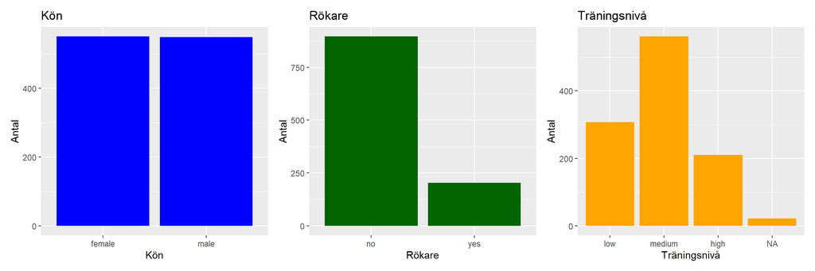

```r
p1 <- ggplot(cost_clean, aes(x = sex)) +
  geom_bar(fill = "blue") +
  labs(title = "Kön", x = "Kön", y = "Antal")

p2 <- ggplot(cost_clean, aes(x = smoker)) +
  geom_bar(fill = "darkgreen") +
  labs(title = "Rökare", x = "Rökare", y = "Antal")

p3 <- ggplot(cost_clean, aes(x = exercise_level)) +
  geom_bar(fill = "orange") +
  labs(title = "Träningsnivå", x = "Träningsnivå", y = "Antal")

p1 + p2 + p3
```

### Fördelning av kostnader

```r
cost_clean %>%
  group_by(smoker) %>%
  summarise(
    medelvärde = mean(charges, na.rm = TRUE),
    median = median(charges, na.rm = TRUE),
    sd = sd(charges, na.rm = TRUE),
    antal = n(),
    .groups = "drop"
  ) %>%
  knitr::kable(caption = "Kostnader per rökarstatus", digits = 0)
```

Kostnader per rökarstatus

| smoker | medelvärde | median | sd | antal |
| --- | --- | --- | --- | --- |
| no | 8586 | 8232 | 3274 | 896 |
| yes | 16537 | 16392 | 3779 | 204 |

```r
cost_clean %>%
  filter(!is.na(exercise_level)) %>%
  group_by(exercise_level) %>%
  summarise(
    medelvärde = mean(charges, na.rm = TRUE),
    median = median(charges, na.rm = TRUE),
    sd = sd(charges, na.rm = TRUE),
    antal = n(),
    .groups = "drop"
  ) %>%
  knitr::kable(caption = "Kostnader per träningsnivå", digits = 0)
```

Kostnader per träningsnivå

| exercise_level | medelvärde | median | sd | antal |
| --- | --- | --- | --- | --- |
| low | 11576 | 10406 | 4920 | 307 |
| medium | 9753 | 8807 | 4393 | 561 |
| high | 8639 | 7723 | 3966 | 210 |

```r
cost_clean %>%
  filter(!is.na(bmi_category)) %>%
  group_by(bmi_category) %>%
  summarise(
    medelvärde = mean(charges, na.rm = TRUE),
    median = median(charges, na.rm = TRUE),
    sd = sd(charges, na.rm = TRUE),
    antal = n(),
    .groups = "drop"
  ) %>%
  knitr::kable(caption = "Kostnader per BMI-kategori", digits = 0)
```

Kostnader per BMI-kategori

| bmi_category | medelvärde | median | sd | antal |
| --- | --- | --- | --- | --- |
| undervikt | 8343 | 7145 | 4044 | 32 |
| normalvikt | 9218 | 8532 | 4397 | 285 |
| övervikt | 10119 | 9032 | 4391 | 450 |
| fetma | 10910 | 9845 | 4863 | 305 |

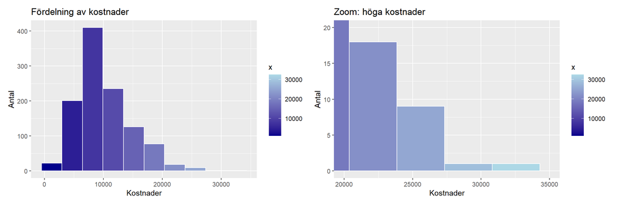

```r
pc1 <- ggplot(cost_clean, aes(x = charges, fill = after_stat(x))) +
  geom_histogram(bins = 10, color = "white") +
  scale_fill_gradient(low = "darkblue", high = "lightblue") +
  labs(title = "Fördelning av kostnader", x = "Kostnader", y = "Antal")

pc2 <- ggplot(cost_clean, aes(x = charges, fill = after_stat(x))) +
  geom_histogram(bins = 10, color = "white") +
  scale_fill_gradient(low = "darkblue", high = "lightblue") +
  coord_cartesian(xlim = c(20000, 35000), ylim = c(0, 20)) +
  labs(title = "Zoom: höga kostnader", x = "Kostnader", y = "Antal")

pc1 + pc2
```

### Kostnader vs rökning och träning

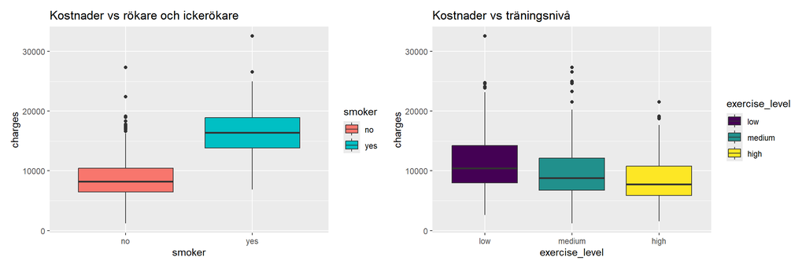

```r
psmo <- ggplot(cost_clean, aes(y = charges, x = smoker, fill = smoker)) +
  geom_boxplot() +
  labs(title = "Kostnader vs rökare och ickerökare")

pfit <- cost_clean %>%
  filter(!is.na(exercise_level)) %>%
  ggplot(aes(y = charges, x = exercise_level, fill = exercise_level)) +
  geom_boxplot() +
  labs(title = "Kostnader vs träningsnivå")

psmo + pfit
```

### Kostnader vs ålder och BMI

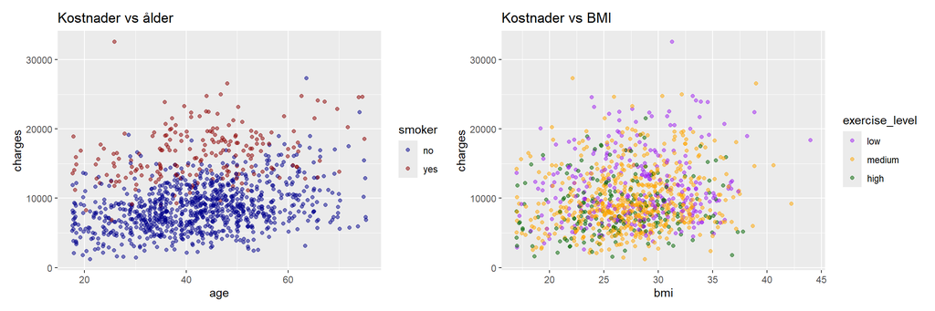

```r
page <- ggplot(cost_clean, aes(y = charges, x = age, color = smoker)) +
  geom_point(alpha = 0.5, position = "jitter") +
  scale_color_manual(values = c("no" = "darkblue", "yes" = "darkred")) +
  labs(title = "Kostnader vs ålder")

pbmi <- cost_clean %>%
  filter(!is.na(bmi), !is.na(exercise_level)) %>%
  ggplot(aes(y = charges, x = bmi, color = exercise_level)) +
  geom_point(alpha = 0.5, position = "jitter") +
  scale_color_manual(values = c("low" = "purple", "medium" = "orange", "high" = "darkgreen")) +
  labs(title = "Kostnader vs BMI")

page + pbmi
```

### Skillnader mellan grupper

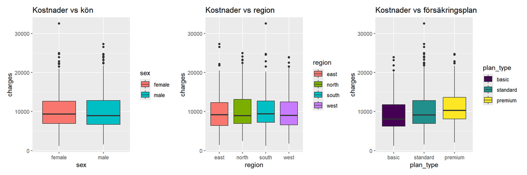

```r
psex <- ggplot(cost_clean, aes(y = charges, x = sex, fill = sex)) +
  geom_boxplot() +
  labs(title = "Kostnader vs kön")

preg <- ggplot(cost_clean, aes(y = charges, x = region, fill = region)) +
  geom_boxplot() +
  labs(title = "Kostnader vs region")

ppla <- ggplot(cost_clean, aes(y = charges, x = plan_type, fill = plan_type)) +
  geom_boxplot() +
  labs(title = "Kostnader vs försäkringsplan")

psex + preg + ppla
```